# HW1

Ting An Lai

2019-09-23

## 1. Import packages and data

```r
if (!require("devtools")) install.packages('devtools')

if (!require("kableExtra")) install.packages ('kableExtra')
if (!require("ggplot2")) install.packages ('ggplot2')
devtools::install_github("rudeboybert/fivethirtyeight")
library(fivethirtyeight)
library(knitr)
data(package = "fivethirtyeight")
```

## 2. Get some data

### Data Description:

American Health Care Act Poll is a 15 observations and 7 variables dataframe. The 15 observations are 15 times pollings from 15 pollsters for general public’s attitude to American Health Care Act. This ahca_poll data was visualized in the original article to support the argument that Republican’s current Health Care Act bill has negative net approval ratings, even worse than the net approval ratings of Obamacare in 2010. Original article: https://fivethirtyeight.com/features/why-the-gop-is-so-hell-bent-on-passing-an-unpopular-health-care-bill/.

```r
head(ahca_polls)
```

```
## # A tibble: 6 x 7
##   start      end        pollster   favor oppose url           text
##   <date>     <date>     <fct>      <int>  <int> <chr>         <chr>
## 1 2017-06-09 2017-06-11 Public Po…    24     55 http://www.p… Do you suppo…
## 2 2017-06-04 2017-06-06 YouGov        33     45 https://d25d… Do you appro…
## 3 2017-05-31 2017-06-06 Qunnipiac     17     62 https://poll… There is a r…
## 4 2017-05-26 2017-05-30 IPSOS         30     46 https://www.… Based on eve…
## 5 2017-05-25 2017-05-30 Morning C…    38     47 https://morn… As you may k…
## 6 2017-05-17 2017-05-23 Quinnipiac    20     57 https://poll… There is a r…
```

### A dataframe with two columns: variable names and variable descriptions.

```r
variable_descriptions = c('the date polling started.',  'the date polling ended.', 'the pollster entity.', 'the 100-scale ratings of favoribility to the ahca bill.', 'the 100-scale rating  of opposing  to the  ahca bill.', 'the original polling source.', 'the original polling question.')
variable_names  = colnames (ahca_polls)
df.var = data.frame(variable_names,  variable_descriptions)
df.var
```

```
##   variable_names                                   variable_descriptions
## 1          start                               the date polling started.
## 2            end                                 the date polling ended.
## 3       pollster                                    the pollster entity.
## 4          favor the 100-scale ratings of favoribility to the ahca bill.
## 5         oppose   the 100-scale rating  of opposing  to the  ahca bill.
## 6            url                            the original polling source.
## 7           text                          the original polling question.
```

## 3. Show data

### A simple summary of the data

```
##      start                 end                                 pollster
##  Min.   :2017-05-04   Min.   :2017-05-06   YouGov                  :4
##  1st Qu.:2017-05-08   1st Qu.:2017-05-14   Morning Consult         :2
##  Median :2017-05-13   Median :2017-05-20   Public Policy Polling   :2
##  Mean   :2017-05-17   Mean   :2017-05-21   Quinnipiac              :2
##  3rd Qu.:2017-05-25   3rd Qu.:2017-05-30   IPSOS                   :1
##  Max.   :2017-06-09   Max.   :2017-06-11   Kaiser Family Foundation:1
##                                            (Other)                 :3
##      favor           oppose          url                text
##  Min.   :17.00   Min.   :44.00   Length:15          Length:15
##  1st Qu.:23.50   1st Qu.:46.50   Class :character   Class :character
##  Median :31.00   Median :48.00   Mode  :character   Mode  :character
##  Mean   :28.33   Mean   :50.67
##  3rd Qu.:31.50   3rd Qu.:55.00
##  Max.   :38.00   Max.   :62.00
##
```

### Interactive datatable

|  | start | end | pollster | favor | oppose |
| --- | --- | --- | --- | --- | --- |
| 1 | 2017-06-09 | 2017-06-11 | Public Policy Polling | 24 | 55 |
| 2 | 2017-06-04 | 2017-06-06 | YouGov | 33 | 45 |
| 3 | 2017-05-31 | 2017-06-06 | Qunnipiac | 17 | 62 |
| 4 | 2017-05-26 | 2017-05-30 | IPSOS | 30 | 46 |
| 5 | 2017-05-25 | 2017-05-30 | Morning Consult | 38 | 47 |
| 6 | 2017-05-17 | 2017-05-23 | Quinnipiac | 20 | 57 |
| 7 | 2017-05-16 | 2017-05-22 | Kaiser Family Foundation | 31 | 55 |
| 8 | 2017-05-13 | 2017-05-20 | Monmouth | 32 | 55 |
| 9 | 2017-05-13 | 2017-05-16 | YouGov | 31 | 47 |
| 10 | 2017-05-12 | 2017-05-16 | Public Policy Polling | 25 | 52 |

[output cut: 5 more lines]

### Non-interactive kable

- Chose the sensible subset of polling date, pollsters, and attitude ratings, eliminating the url and survey text columns.
- Prettified the column names with capitalization and more details.

| Poll_Start_Date | Poll_End_Date | Pollster_Entity | Favor_Attitude | Oppose_Attitude | Net_Approval_Ratings |
| --- | --- | --- | --- | --- | --- |
| 2017-06-09 | 2017-06-11 | Public Policy Polling | 24 | 55 | -31 |
| 2017-06-04 | 2017-06-06 | YouGov | 33 | 45 | -12 |
| 2017-05-31 | 2017-06-06 | Qunnipiac | 17 | 62 | -45 |
| 2017-05-26 | 2017-05-30 | IPSOS | 30 | 46 | -16 |
| 2017-05-25 | 2017-05-30 | Morning Consult | 38 | 47 | -9 |
| 2017-05-17 | 2017-05-23 | Quinnipiac | 20 | 57 | -37 |
| 2017-05-16 | 2017-05-22 | Kaiser Family Foundation | 31 | 55 | -24 |
| 2017-05-13 | 2017-05-20 | Monmouth | 32 | 55 | -23 |
| 2017-05-13 | 2017-05-16 | YouGov | 31 | 47 | -16 |
| 2017-05-12 | 2017-05-16 | Public Policy Polling | 25 | 52 | -27 |
| 2017-05-11 | 2017-05-15 | NBC/WSJ | 23 | 48 | -25 |
| 2017-05-06 | 2017-05-13 | YouGov | 31 | 44 | -13 |
| 2017-05-06 | 2017-05-06 | YouGov | 31 | 47 | -16 |
| 2017-05-04 | 2017-05-10 | Quinnipiac | 21 | 56 | -35 |
| 2017-05-04 | 2017-05-09 | Morning Consult | 38 | 44 | -6 |

- Created two new variable **Net_Approval_Ratings** and **Amount_of_Words_in_Question** through functions (hidden in codes).

## 5. Add a plot

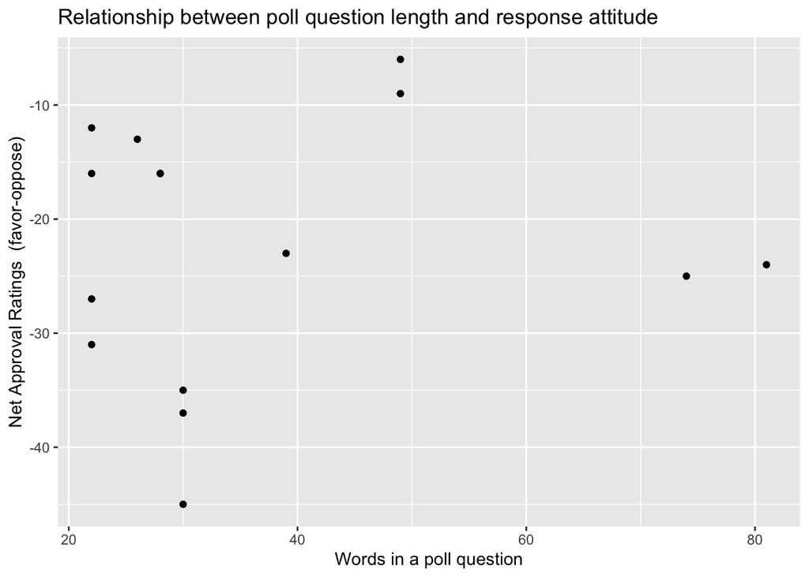

```r
ahca_polls_sub_col[7] <- text_length
colnames (ahca_polls_sub_col) <- c('Poll_Start_Date', 'Poll_End_Date', 'Pollster_Entity', 'Favor_Attitude', 'Oppose_Attitude', 'Net_Approval_Ratings', 'Text_Length')
b <- ggplot (ahca_polls_sub_col, aes(x = Text_Length, y = Net_Approval_Ratings ))  + geom_point()
print (b +  ggtitle  ('Relationship between poll question length and response attitude') + labs (y  = "Net Approval Ratings  (favor-oppose)",  x  =  "Words in a poll question"))
```

## 6. Add a picture

A picture of how questionnaire design influences answer qualities

[figure not shown]

> The picture origin. [^1]

## 7. More Markdown

The url source of the picture.

[^1]: https://www.cartoonstock.com/directory/q/questionnaires.asp